# COMPSCIX 415.2 Take-Home Final

Gwen Rino

3/28/2018

```r
library(tidyverse)
library(modelr)
library(rpart)
library(partykit)
library(randomForest)
library(ROCR)
```

## BOOTSTRAPPING

### Question 1

```r
# Load data
titanic <- read_csv("Titanic.csv")
# Convert all character columns to unordered factors
titanic <- as.data.frame(unclass(titanic))
# Acknowledgment of quick method for converting all character columns to factors at once:
# https://stackoverflow.com/questions/20637360/convert-all-data-frame-character-columns-to-factors

# Convert Survived and Pclass to unordered factors
titanic$Survived <- factor(titanic$Survived)
titanic$Pclass <- factor(titanic$Pclass)

# Convert it back to a tibble
titanic <- as.tibble(titanic)

# To confirm all is well
glimpse(titanic)
```

```
## Observations: 891
## Variables: 12
## $ PassengerId <int> 1, 2, 3, 4, 5, 6, 7, 8, 9, 10, 11, 12, 13, 14, 15,...
## $ Survived    <fct> 0, 1, 1, 1, 0, 0, 0, 0, 1, 1, 1, 1, 0, 0, 0, 1, 0,...
## $ Pclass      <fct> 3, 1, 3, 1, 3, 3, 1, 3, 3, 2, 3, 1, 3, 3, 3, 2, 3,...
## $ Name        <fct> Braund, Mr. Owen Harris, Cumings, Mrs. John Bradle...
## $ Sex         <fct> male, female, female, female, male, male, male, ma...
## $ Age         <dbl> 22, 38, 26, 35, 35, NA, 54, 2, 27, 14, 4, 58, 20, ...
## $ SibSp       <int> 1, 1, 0, 1, 0, 0, 0, 3, 0, 1, 1, 0, 0, 1, 0, 0, 4,...
## $ Parch       <int> 0, 0, 0, 0, 0, 0, 0, 1, 2, 0, 1, 0, 0, 5, 0, 0, 1,...
## $ Ticket      <fct> A/5 21171, PC 17599, STON/O2. 3101282, 113803, 373...
## $ Fare        <dbl> 7.2500, 71.2833, 7.9250, 53.1000, 8.0500, 8.4583, ...
## $ Cabin       <fct> NA, C85, NA, C123, NA, NA, E46, NA, NA, NA, G6, C1...
## $ Embarked    <fct> S, C, S, S, S, Q, S, S, S, C, S, S, S, S, S, S, Q,...
```

### Question 2

The output confirms that this is a tibble with a list column of resample objects.

```r
# Take 100 bootstrap samples of the data
titanic_boot <- bootstrap(data = titanic, n = 100)
titanic_boot
```

```
## # A tibble: 100 x 2
##    strap          .id
##    <list>         <chr>
##  1 <S3: resample> 001
##  2 <S3: resample> 002
##  3 <S3: resample> 003
##  4 <S3: resample> 004
##  5 <S3: resample> 005
##  6 <S3: resample> 006
##  7 <S3: resample> 007
##  8 <S3: resample> 008
##  9 <S3: resample> 009
## 10 <S3: resample> 010
## # ... with 90 more rows
```

### Question 3

```r
as.tibble(titanic_boot$strap[[1]]) %>% n_distinct()
```

```
## [1] 560
```

```r
as.tibble(titanic_boot$strap[[2]]) %>% n_distinct()
```

```
## [1] 564
```

```r
as.tibble(titanic_boot$strap[[3]]) %>% n_distinct()
```

```
## [1] 560
```

### Question 4

```r
# Create a function that pulls out the mean of Age from each bootstrap sample
age_mean <- function(x) {
  data <- as.tibble(x) # Convert input data set to a tibble
  mean_age <- mean(data$Age, na.rm = TRUE) # Take the mean of Age, remove NAs
  return(mean_age) # Return the mean of Age
}

# Make an empty vector of 100 NAs
all_means <- rep(NA, 100)

# Create a loop that fills the empty vector using the function age_mean
for(i in 1:100) {
  all_means[i] <- age_mean(titanic_boot$strap[[i]])
}

# Take a look at some of the means you calculated from your samples
head(all_means)
```

```
## [1] 29.59399 29.85854 29.70501 30.17777 30.06297 29.71946
```

```r
# Convert to a tibble so we can use it for plotting
all_means <- tibble(all_means = all_means)
```

### Question 5

The histogram shows the distribution of mean Age in the bootstrap samples.

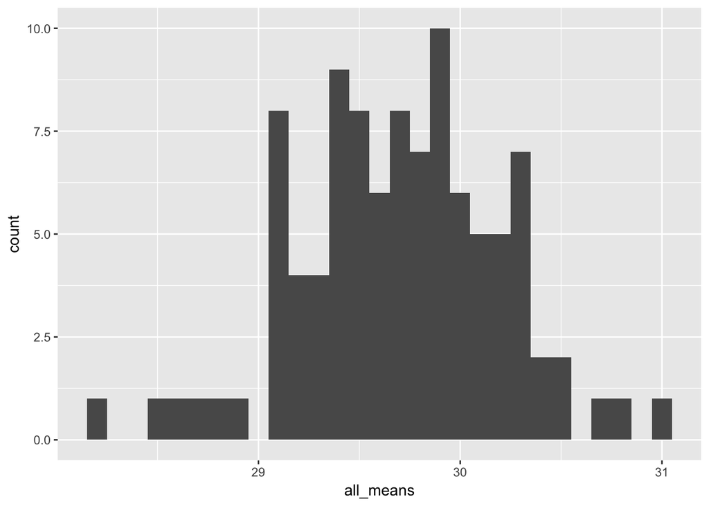

```r
ggplot(data = all_means) +
  geom_histogram(aes(x = all_means), binwidth = .1)
```

### Question 6

The theoretical standard error of the sample mean of Age and the standard error calculated from the bootstrap sample means are pretty close, both around 0.5. The Central Limit Theorem holds!

```r
# Standard error of sample mean of Age using bootstrap sample means
sd(all_means$all_means)
```

```
## [1] 0.4951
```

```r
# Theoretical standard error of sample mean of Age
sd(titanic$Age, na.rm = TRUE)/sqrt(nrow(titanic))
```

```
## [1] 0.486656
```

## RANDOM FOREST

### Question 1

```r
# Split training and test sets
set.seed(987)
model_data <- resample_partition(titanic, c(test = 0.3, train = 0.7))
train_set <- as.tibble(model_data$train)
test_set <- as.tibble(model_data$test)
```

### Question 2

The “upstream” nodes of this decision tree model are the same or very nearly the same as last week’s tree model. These are the first node, which splits males from females, the fifth node, which splits female passengers by Pclass, the sixth node, which splits third class female passengers by Fare with the cutoff at about $23, and the eighth node, which splits third class female passengers who paid lower fares by Fare with the cutoff at $7.89. This model also has several changed or new nodes in comparison to last week’s tree model, all splitting on the Age feature. It is noteworthy that the features SibSp, Parch, and Embarked do not play a role in this decision tree.

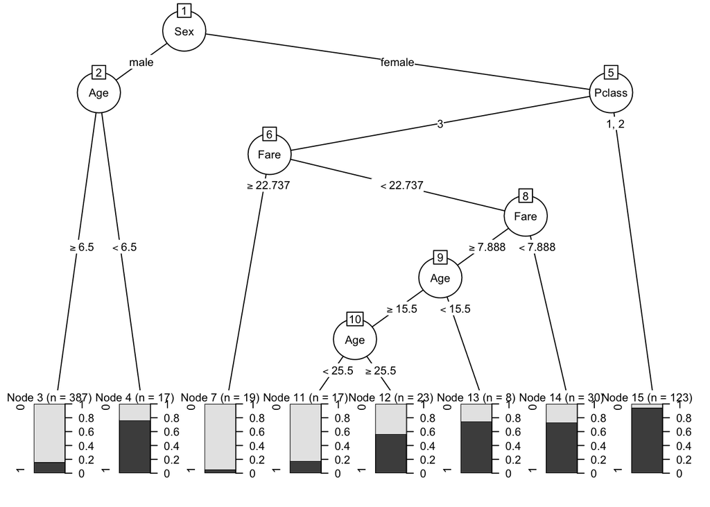

```r
# Fit the decision tree model
tree_mod <- rpart(Survived ~ Pclass + Sex + Age + SibSp + Parch + Fare + Embarked,
                  data = train_set)
# Visualize the tree
plot(as.party(tree_mod), gp=gpar(fontsize = 8))
```

```r
# Acknowledgment of method for changing font size in decision tree plot:
# https://stackoverflow.com/questions/13751962/how-to-plot-a-large-ctree-to-avoid-overlapping-nodes
```

### Question 3

```r
# Fit the random forest model
rf_mod <- randomForest(Survived ~ Pclass + Sex + Age + SibSp + Parch + Fare + Embarked,
                         data = train_set,
                         ntrees = 500,
                         mtry = 4,
                         na.action = na.roughfix)
```

### Question 4

A comparison of the AUCs for the two models shows that the random forest model performs better than the decision tree model.

```r
# Get the predictions from each model for the test set
rf_preds <- predict(rf_mod, newdata = test_set, type = 'prob')[,2]
tree_preds <- predict(tree_mod, newdata = test_set)[,2]

# Create the prediction objects for each model
pred_rf <- prediction(predictions = rf_preds, labels = test_set$Survived)
pred_tree <- prediction(predictions = tree_preds, labels = test_set$Survived)

# Calculate the AUCs
auc_rf <- performance(pred_rf, measure = "auc")
auc_tree <- performance(pred_tree, measure = "auc")

# Extract the AUC value for the random forest model
auc_rf@y.values[[1]]
```

```
## [1] 0.8635955
```

```r
# Extract the AUC value for the decision tree model
auc_tree@y.values[[1]]
```

```
## [1] 0.7903037
```

### Question 5

```r
# Get the FPR and TPR for the random forest model
perf_rf <- performance(pred_rf, measure = 'tpr', x.measure = 'fpr')
perf_rf_tbl <- tibble(perf_rf@x.values[[1]], perf_rf@y.values[[1]])

# Change the names of the columns of the tibble
names(perf_rf_tbl) <- c('fpr', 'tpr')

# Get the FPR and TPR for the tree model
perf_tree <- performance(pred_tree, measure = 'tpr', x.measure = 'fpr')
perf_tree_tbl <- tibble(perf_tree@x.values[[1]], perf_tree@y.values[[1]])

# Change the names of the columns of the tibble
names(perf_tree_tbl) <- c('fpr', 'tpr')

# Combine the two tibbles
all_perf_tbl <- bind_rows(perf_tree_tbl, perf_rf_tbl)
```

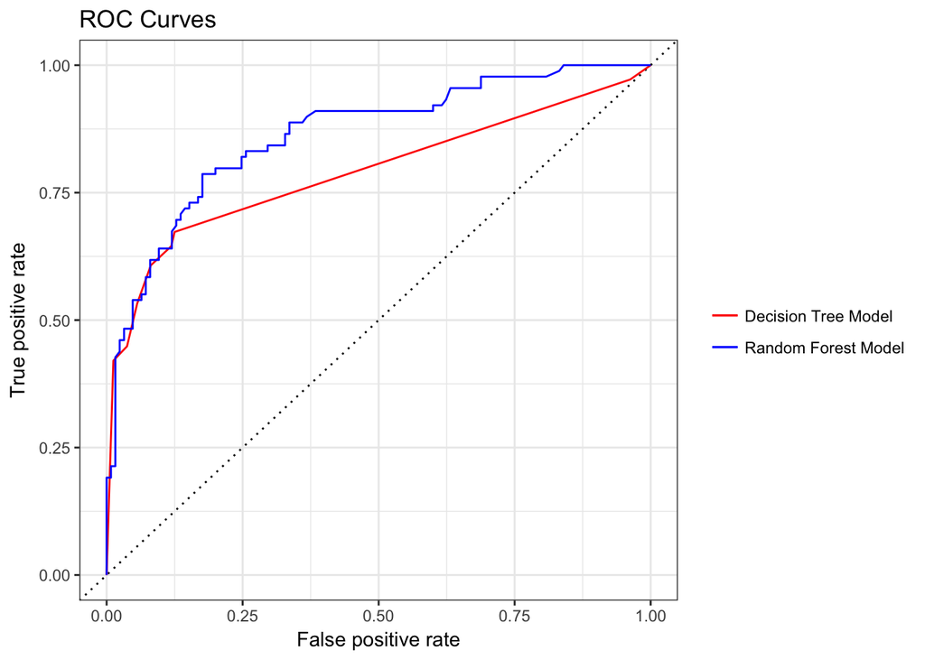

```r
p = ggplot(data = all_perf_tbl) +
  geom_abline(intercept = 0, slope = 1, lty = 3) +
  labs(x = 'False positive rate', y = 'True positive rate',
       title = 'ROC Curves') +
  geom_line(data = all_perf_tbl[1:9,], aes(x=fpr, y=tpr, color = 'Decision Tree Model')) +
  geom_line(data = all_perf_tbl[10:167,], aes(x=fpr, y=tpr, color = 'Random Forest Model')) +
  scale_color_manual(" ",
                     breaks = c('Decision Tree Model', 'Random Forest Model'),
                     values = c('red', 'blue')) +
  theme_bw()

p
```

```r
# Acknowledgment of method for creating the legend:
# https://stackoverflow.com/questions/10349206/add-legend-to-ggplot2-line-plot
```

### Question 6

1. The random forest model performs better than the decision tree model.
2. At a true positive rate of 0.75, the decision tree model’s false positive rate is about 0.33 while the random forest model’s false positive rate is about 0.17. That’s a really big difference!